# Editing Inventory in Single-player Games

Using Cheat Engine 7.1 (Example Game: Baldur’s Gate 3)

Luke Patterson

## Introduction

**Cheat Engine** is a powerful open-source memory scanner and debugger. It can be used to probe the data a game is using in real time. Using it to do so the values in memory can be edited to the user’s choice. This can be instrumental in modifying games but can also be a fun tool to play around with and use to duplicated items. In This tutorial the reader will see how to open a running process for observation, how to find a desired value, and how to actually edit the value.

## Installation

#### Requirements:

- Cheat Engine
- A Game (Baldur’s Gate 3)

#### Cheat Engine:

A download for Cheat Engine 7.1 can be found by visiting https://www.cheatengine.org/ and selecting downloads. There will be a link for a Windows version as well as Mac version depending on your machine.

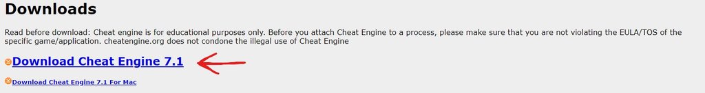

After downloading run the executable, this will install Cheat Engine. Now restart your machine and it will be ready to use.

#### Baldur’s Gate 3:

The same logic will follow for the majority of single player games but for this tutorial we will be using Baldur’s Gate 3. It can be found for purchase here: https://store.steampowered.com/app/1086940/Baldurs_Gate_3/

[figure not shown]

## FAQ

- Is Cheat Engine free?

Yes, Cheat Engine is totally free and open-source.

- Does this work in multiplayer games?

No, due to how memory is stored in multiplayer games this particular methodology does not work in most online games.

- Is Cheat Engine just for hacking/cheating?

No, Cheat Engine is actually used for many professional purposes as well as being a powerful tool for modding communities interested in creating custom content for games.

## Troubleshooting

For any trouble concerning Cheat Engine there is an extensive forum at https://forum.cheatengine.org/ that can offer community help as well as a contact email for the creator listed at https://www.cheatengine.org/aboutce.php

## Getting Started with Cheat Engine

When launching Cheat Engine be sure to allow it access to your computer and running processes. On first opening it should appear similar to this:

[figure not shown]

Great! Now that we Cheat Engine open let’s go ahead and launch our game. Once the game is running head back to Cheat Engine and select the open process button which is located just below “File” on the top left section of the program.

[figure not shown]

It will bring up a dialog box listing all the running processes on your computer. Select the one you’re looking for (Baldur’s Gate 3) and hit open.

[figure not shown]

Now we’re ready to find the item!

## Finding Desired Value

Once we’re inside our game we can open the inventory and pick out the item we want to duplicate or edit. Today we’re going to pick Potion of Healing in Baldur’s Gate 3. When you pick an item it will be easier to find in Cheat Engine if you have multiple of them in your inventory, luckily we have 7 Potions of Healing at the moment!

[figure not shown]

When you have the number of the item currently in your inventory head over to Cheat Engine and type that value into the “Value:” textbox then hit “First Scan”

[figure not shown]

Oh my! Nearly 900,000 7’s stored in memory currently. That’s too many to go through so let’s refine our search a little.

- Going into your game reduce or add to the number of items in the stack in your inventory. I’m going to be splitting my stack by taking 4 off.
- Since there are 3 potions left in the stack let’s go over to Cheat Engine and type 3 in for the value and press “Next Scan” This will look through the values we found before and find any that changed from 7 to 3.

[figure not shown]

Nice! That reduced our number of values from ~900,000 to only 216. That’s still too many to figure out which is pointing to our health potions though. Let’s continue this method of changing the value and scanning a few more times.

[figure not shown]

[figure not shown]

Eventually you’ll reach a few values (usually around 1-10) that will follow the value of the item exactly. Having multiple values is normal since some of these values are used to print numbers on the screen and keep track of inventory in multiple parts of the game.

## Editing the Value

With the few values we’ve found we can go ahead and assume editing them would change the number of potions we would have in our inventory. **Changing values in memory can be dangerous and you should always create a savefile for your game before tinkering with any memory.** To change the value we will edit all of the values at each listed memory address.

- Click the first address and while holding shift click the final address in the list.
- With them hilighted right click and select “Change value of selected addresses”

[figure not shown]

In the dialog box that opens:

- Type the number of items you want in your inventory
- Press okay

Once you’re done return to the game and you should see the new value displayed. If not do an action to refresh the number printed on the screen such as closing and opening your inventory or moving the item around.

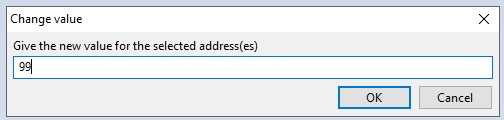

[figure not shown]

As you can see the number of health potions is no longer 7 but instead 99!

## Contribute and Licensing

I am in no way affiliated with Cheat Engine or its makers nor do I have any affiliation with the game Baldur’s Gate 3 or Larian Studios. I do not encourage or promote the use of Cheat Engine to modify software in an way that breaks user agreements. This tutorial was for purely educational purposes.

If you are interested in contributing to Cheat Engine you can check out https://cheatengine.org/contribute.php which gives instructions for doing so.